# Survival Analysis on Heroin Addiction Data in R

Now, Our interest is to estimate what is the retention probability at a certain time say $t$, which is nothing but Survival probability at a certain time,$S(t)$.

The survival function, is the probability an individual survives (or, the probability that the event of interest does not occur) up to and including time $t$. It’s the probability that the event (e.g., death) hasn’t occured yet. It looks like this, where $T$ is the time of death, and $P(T>t)$ is the probability that the time of death is greater than some time $t$.

There are various techniques to estimate this retention probability or survival probability, one of them is **Product Limit estimation/Kaplan-Meier** estimation.

In R the `survfit()` function under `survival` package; estimates median survival with 95% C.I and creates survival curves based on a formula.

```r
## Estimated Median
data$status_code= (data$status=="endpoint")*1
f1=survfit(Surv(time, status_code)~1,data=data)
f1
```

```
## Call: survfit(formula = Surv(time, status_code) ~ 1, data = data)
##
##        n events median 0.95LCL 0.95UCL
## [1,] 238    150    504     394     560
```

```r
summary(f1)
```

```
## Call: survfit(formula = Surv(time, status_code) ~ 1, data = data)
##
##  time n.risk n.event survival std.err lower 95% CI upper 95% CI
##     7    236       1    0.996 0.00423       0.9875        1.000
##    13    235       1    0.992 0.00597       0.9799        1.000
##    17    234       1    0.987 0.00729       0.9731        1.000
##    19    233       1    0.983 0.00840       0.9667        1.000
##    26    232       1    0.979 0.00937       0.9606        0.997
##    29    229       1    0.975 0.01026       0.9546        0.995
##    30    228       1    0.970 0.01107       0.9488        0.992
##    33    227       1    0.966 0.01182       0.9431        0.989
##    35    226       2    0.957 0.01317       0.9320        0.984
##    37    224       1    0.953 0.01379       0.9265        0.981
##    41    223       2    0.945 0.01493       0.9158        0.974
##    44    221       1    0.940 0.01546       0.9105        0.971
```

[output cut: 128 more lines]

We can give the `summary()` function an option for what times we want to show in the results.

```r
summary(f1,times = c(10,50,100,150,200,250,300,350,400))
```

```
## Call: survfit(formula = Surv(time, status_code) ~ 1, data = data)
##
##  time n.risk n.event survival std.err lower 95% CI upper 95% CI
##    10    235       1    0.996 0.00423        0.988        1.000
##    50    218      16    0.928 0.01693        0.895        0.961
##   100    202       9    0.888 0.02064        0.849        0.930
##   150    186      12    0.835 0.02451        0.788        0.884
##   200    167      15    0.766 0.02818        0.713        0.824
##   250    150      14    0.701 0.03069        0.644        0.764
##   300    136      13    0.640 0.03234        0.580        0.707
##   350    124       7    0.607 0.03305        0.545        0.675
##   400    110      10    0.557 0.03390        0.494        0.627
```

Note that, by default R does not report mean survival. To get the mean survival:

```r
print(f1,print.rmean=T)
```

```
## Call: survfit(formula = Surv(time, status_code) ~ 1, data = data)
##
##        n events rmean* se(rmean) median 0.95LCL 0.95UCL
## [1,] 238    150    517      24.4    504     394     560
##     * restricted mean with upper limit =  1076
```

### 0.9.1 Kaplan-Meier Plots:

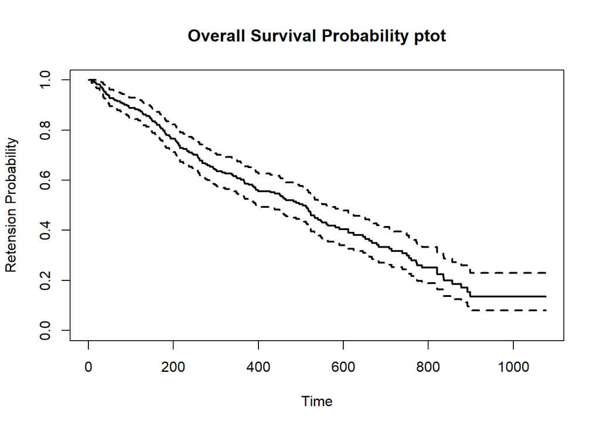

```r
plot(f1,
     xlab = "Time",
     ylab="Retension Probability",
     main="Overall Survival Probability ptot",
     lwd=2)
box()
```

### 0.9.2 Cumulative Probability

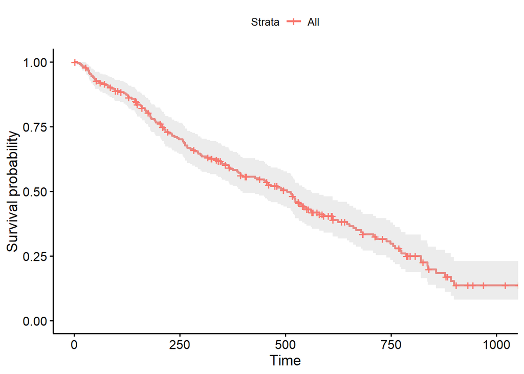

```r
##-- Simple Survival plot
ggsurvplot(f1, data = data, conf.int = T,legend="top")+xlab("Time")
```

```r
#surv.median.line = "hv"
```

Here, in the above this is the overall survival curve. But where is the Median Survival value? To draw it…

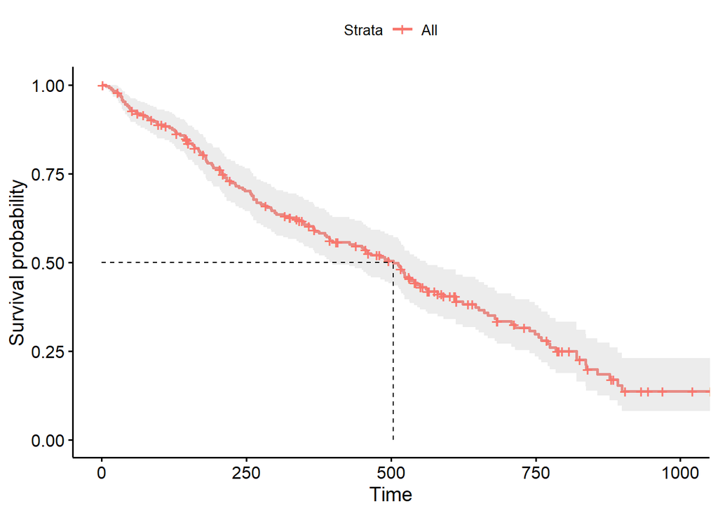

```r
ggsurvplot(f1, data = data, conf.int = T,legend="top",surv.median.line = "hv")+xlab("Time")
```

Alternatively,

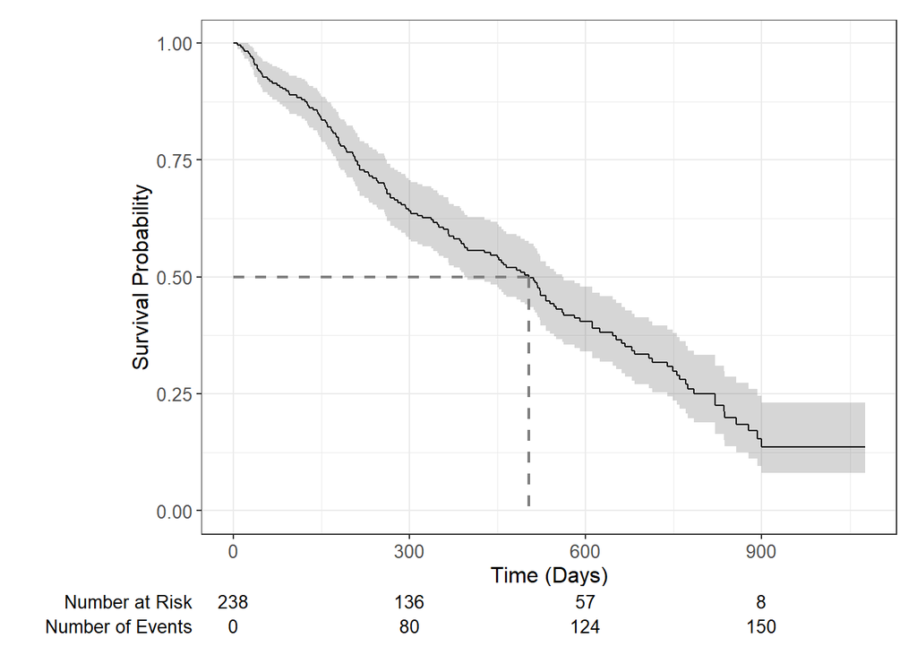

```r
survfit2(Surv(time, status_code) ~ 1, data = data) %>%
  ggsurvfit()+add_confidence_interval()+add_quantile(y_value = 0.5, color = "gray50", linewidth = 0.75)+
  labs(x="Time (Days)",y="Survival Probability")+
  add_risktable(risktable_stats = c("n.risk","cum.event"),stats_label = list(n.risk = "Number at Risk",cum.event="Number of Events"))
```

## 0.10 Q(2). Compare the retention probabilities between the two clinics using the appropriate test.

```r
f2=survfit(Surv(time, status_code)~clinic,data=data)
print(f2,print.rmean = T)
```

```
## Call: survfit(formula = Surv(time, status_code) ~ clinic, data = data)
##
##                  n events rmean* se(rmean) median 0.95LCL 0.95UCL
## clinic=Clinic1  75     28    732      50.5     NA     661      NA
## clinic=Clinic2 163    122    432      23.3    399     341     514
##     * restricted mean with upper limit =  1076
```

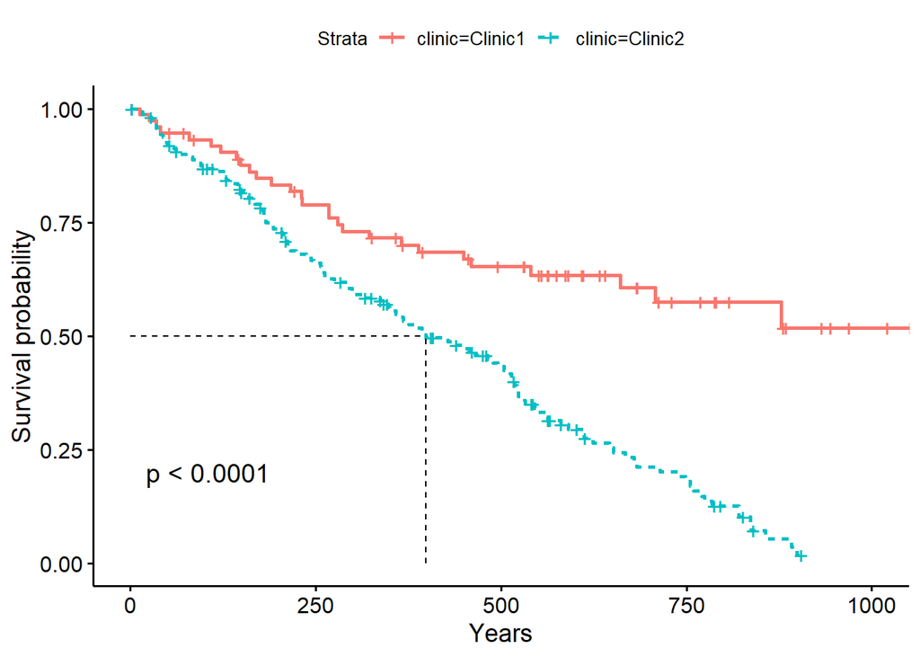

```r
## Survival  Plot
ggsurvplot(f2, data = data,linetype = "strata",pval = TRUE, surv.median.line = "hv",conf.int = F,legend="top")+xlab("Years")
```

Similarly we can also estimate retention probabilities for other factors:

```r
### For Prison record---:

##-- Median Estimate with 95% C.I
f2=survfit(Surv(time, status_code)~pris_rec,data=data)
f2
```

```
## Call: survfit(formula = Surv(time, status_code) ~ pris_rec, data = data)
##
##                 n events median 0.95LCL 0.95UCL
## pris_rec=none 127     81    523     460     652
## pris_rec=any  111     69    394     268     563
```

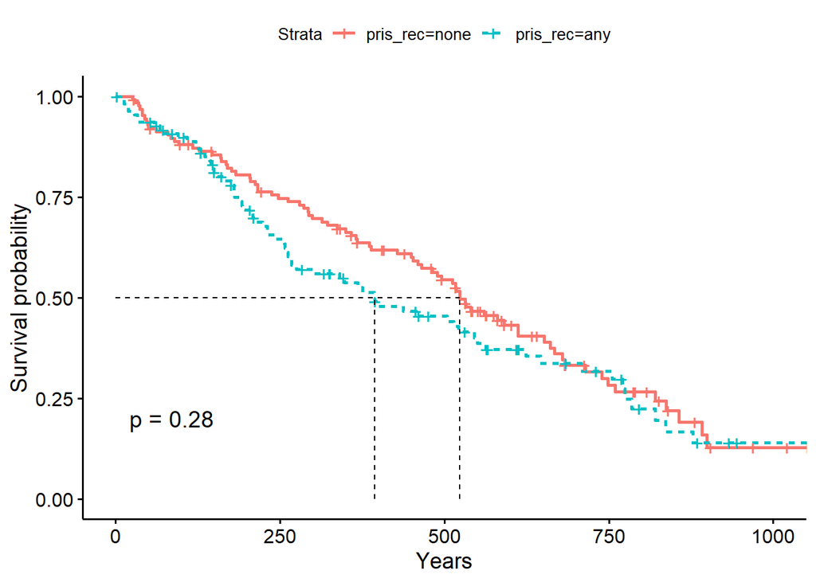

```r
ggsurvplot(f2, data = data,linetype = "strata",pval = TRUE, conf.int = F,surv.median.line = "hv",legend="top")+xlab("Years")
```

```r
### For Dose---:

##-- Median Estimate with 95% C.I
f3=survfit(Surv(time, status_code)~dose,data=data)
f3
```

```
## Call: survfit(formula = Surv(time, status_code) ~ dose, data = data)
##
##           n events median 0.95LCL 0.95UCL
## dose=20   1      1    127      NA      NA
## dose=30   2      2    332     183      NA
## dose=35   2      2    420     160      NA
## dose=40  30     18    223     117      NA
## dose=45  10      7    322      84      NA
## dose=50  27     15    460     216      NA
## dose=55  21     20    366     262     450
## dose=60  52     37    399     257     708
## dose=65  22     17    496     337      NA
## dose=70  24     14    563     314      NA
## dose=75   6      3    771     771      NA
## dose=80  35     12     NA     785      NA
## dose=90   2      1    280     280      NA
## dose=100  3      1     NA     216      NA
## dose=110  1      0     NA      NA      NA
```

```r
### For LI record---:

##-- Median Estimate with 95% C.I/
f4=survfit(Surv(time, status_code)~LI,data=data)
f4
```

```
## Call: survfit(formula = Surv(time, status_code) ~ LI, data = data)
##
##        n events median 0.95LCL 0.95UCL
## LI=7   2      0     NA      NA      NA
## LI=8   5      0     NA      NA      NA
## LI=9   4      0     NA      NA      NA
## LI=10  3      0     NA      NA      NA
## LI=11  4      0     NA      NA      NA
## LI=12  9      1     NA      NA      NA
## LI=13  9      0     NA      NA      NA
## LI=14 14      0     NA      NA      NA
## LI=15 16      4     NA     612      NA
## LI=16 19     12    280     207      NA
## LI=17 17      9    223     161      NA
## LI=18 18     14    394     358      NA
## LI=19 17     16    314     190     679
## LI=20 33     28    399     337     560
## LI=21 24     23    366     216     540
## LI=22 20     19    275     247     624
## LI=23 10     10    228     127      NA
## LI=24  4      4    318     175      NA
## LI=25  6      6    178      50      NA
## LI=26  4      4    280      79      NA
```

```r
### For Depression---:

##-- Median Estimate with 95% C.I/
f5=survfit(Surv(time, status_code)~Depression,data=data)
f5
```

```
## Call: survfit(formula = Surv(time, status_code) ~ Depression, data = data)
##
##                  n events median 0.95LCL 0.95UCL
## Depression=yes  97     30    785     714      NA
## Depression=no  141    120    322     259     452
```

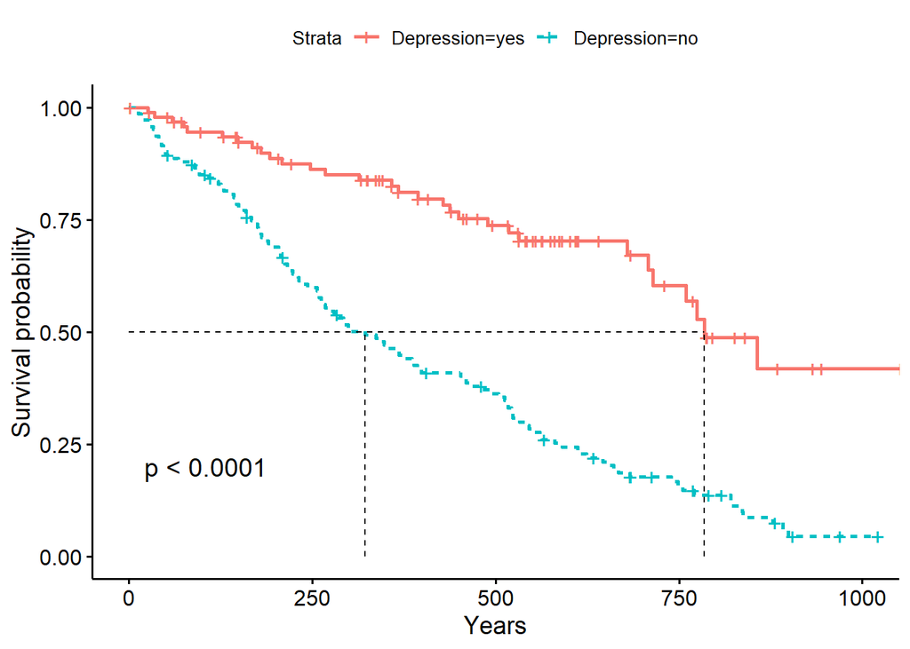

```r
ggsurvplot(f5, data = data,linetype = "strata",pval = TRUE, conf.int = F,surv.median.line = "hv",legend="top")+xlab("Years")
```

So the comparison of retention probabilities between Clinics:

### 0.10.1 Log Rank Test

```r
test= survdiff(Surv(time,status_code)~clinic,data=data)
test
```

```
## Call:
## survdiff(formula = Surv(time, status_code) ~ clinic, data = data)
##
##                  N Observed Expected (O-E)^2/E (O-E)^2/V
## clinic=Clinic1  75       28     59.2      16.4      28.1
## clinic=Clinic2 163      122     90.8      10.7      28.1
##
##  Chisq= 28.1  on 1 degrees of freedom, p= 1e-07
```

The Chi-Squared test statistic is 28.1 with 1 degree of freedom and the corresponding p-value is <0.001. Since this p-value is less than 0.001, we reject the null hypothesis,i.e., $H_0: \text{in terms of retention, there is no difference between two clinics.}$.

In other words, we have sufficient evidence to say that there is a statistically significant difference for retention between the Clinic 1 & Clinic 2.

To, extract the p-value from `survdiff` we use the following trick:

```r
p.val= 1 - pchisq(test$chisq, length(test$n) - 1)

round(p.val,3)
```

```
## [1] 0
```

similarly, the log-rank test for other covariates:

```r
test= survdiff(Surv(time,status_code)~pris_rec,data=data)
print("Prison record:--")
```

```
## [1] "Prison record:--"
```

```r
test
```

```
## Call:
## survdiff(formula = Surv(time, status_code) ~ pris_rec, data = data)
##
##                 N Observed Expected (O-E)^2/E (O-E)^2/V
## pris_rec=none 127       81     87.4     0.474      1.14
## pris_rec=any  111       69     62.6     0.663      1.14
##
##  Chisq= 1.1  on 1 degrees of freedom, p= 0.3
```

```r
test= survdiff(Surv(time,status_code)~dose,data=data)
print("Dose:--")
```

```
## [1] "Dose:--"
```

```r
test
```

```
## Call:
## survdiff(formula = Surv(time, status_code) ~ dose, data = data)
##
##           N Observed Expected (O-E)^2/E (O-E)^2/V
## dose=20   1        1    0.143    5.1221    5.1488
## dose=30   2        2    0.910    1.3073    1.3201
## dose=35   2        2    1.258    0.4382    0.4436
## dose=40  30       18   10.198    5.9682    6.4796
## dose=45  10        7    4.411    1.5202    1.5816
## dose=50  27       15   14.219    0.0429    0.0477
## dose=55  21       20    9.676   11.0153   11.9907
## dose=60  52       37   30.039    1.6133    2.0287
## dose=65  22       17   14.107    0.5933    0.6623
## dose=70  24       14   16.070    0.2667    0.3022
## dose=75   6        3    5.070    0.8453    0.8798
## dose=80  35       12   38.921   18.6209   27.5374
## dose=90   2        1    1.789    0.3478    0.3536
## dose=100  3        1    2.306    0.7396    0.7542
## dose=110  1        0    0.884    0.8843    0.8923
##
##  Chisq= 53.4  on 14 degrees of freedom, p= 2e-06
```

```r
test= survdiff(Surv(time,status_code)~LI,data=data)
print("LI:--")
```

```
## [1] "LI:--"
```

```r
test
```

```
## Call:
## survdiff(formula = Surv(time, status_code) ~ LI, data = data)
##
##        N Observed Expected (O-E)^2/E (O-E)^2/V
## LI=7   2        0     1.20  1.20e+00  1.22e+00
## LI=8   5        0     6.30  6.30e+00  6.77e+00
## LI=9   4        0     2.26  2.26e+00  2.31e+00
## LI=10  3        0     1.74  1.74e+00  1.77e+00
## LI=11  4        0     4.55  4.55e+00  4.73e+00
## LI=12  9        1     7.52  5.65e+00  6.11e+00
## LI=13  9        0     6.97  6.97e+00  7.34e+00
## LI=14 14        0    12.62  1.26e+01  1.39e+01
## LI=15 16        4    10.19  3.76e+00  4.09e+00
## LI=16 19       12     9.73  5.28e-01  5.70e-01
## LI=17 17        9     6.81  7.04e-01  7.42e-01
## LI=18 18       14    13.92  4.43e-04  4.94e-04
## LI=19 17       16    10.27  3.19e+00  3.44e+00
## LI=20 33       28    21.59  1.90e+00  2.23e+00
## LI=21 24       23    13.70  6.31e+00  7.01e+00
## LI=22 20       19    10.07  7.91e+00  8.53e+00
## LI=23 10       10     3.71  1.07e+01  1.10e+01
## LI=24  4        4     2.62  7.31e-01  7.49e-01
## LI=25  6        6     2.65  4.25e+00  4.37e+00
## LI=26  4        4     1.57  3.75e+00  3.81e+00
##
##  Chisq= 87  on 19 degrees of freedom, p= 1e-10
```

```r
test= survdiff(Surv(time,status_code)~Depression,data=data)
print("Depression:--")
```

```
## [1] "Depression:--"
```

```r
test
```

```
## Call:
## survdiff(formula = Surv(time, status_code) ~ Depression, data = data)
##
##                  N Observed Expected (O-E)^2/E (O-E)^2/V
## Depression=yes  97       30     69.7      22.6      42.6
## Depression=no  141      120     80.3      19.7      42.6
##
##  Chisq= 42.6  on 1 degrees of freedom, p= 7e-11
```

## 0.11 Q(3). Check for the Proportional Hazards assumption for each of the independent variables using– (i)Log log survival plot, (ii)Plot Schoenfeld residuals

Kaplan-Meier curves are good for visualizing differences in survival between two categorical groups, but they don’t work well for assessing the effect of quantitative variables like age, gene expression, leukocyte count, etc. Cox PH regression can assess the effect of both categorical and continuous variables, and can model the effect of multiple variables at once.

Let,

```r
Mod1=coxph(Surv(time,status_code)~Depression,data=data)
summary(Mod1)
```

```
## Call:
## coxph(formula = Surv(time, status_code) ~ Depression, data = data)
##
##   n= 238, number of events= 150
##
##                coef exp(coef) se(coef)     z Pr(>|z|)
## Depressionno 1.2532    3.5016   0.2045 6.128  8.9e-10 ***
## ---
## Signif. codes:  0 '***' 0.001 '**' 0.01 '*' 0.05 '.' 0.1 ' ' 1
##
##              exp(coef) exp(-coef) lower .95 upper .95
## Depressionno     3.502     0.2856     2.345     5.228
##
## Concordance= 0.633  (se = 0.021 )
## Likelihood ratio test= 46.26  on 1 df,   p=1e-11
## Wald test            = 37.55  on 1 df,   p=9e-10
## Score (logrank) test = 42.66  on 1 df,   p=7e-11
```

Note that, **Likelihood ratio test**, **Wald test** and **Score test** are the values of the test statistics for testing of hypothesis: $H_0:\text{All}\:\:\beta_s \:\:=0$.

These give the evidence of overall model significance.

## 0.12 Testing proportional Hazards assumption : Log-log plot

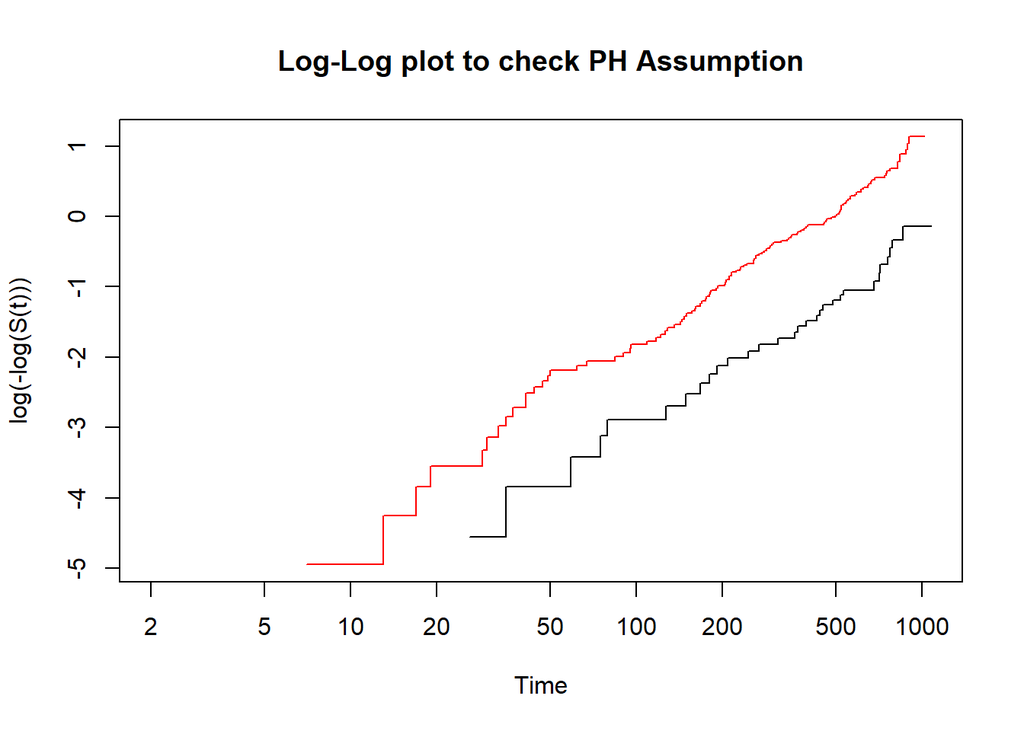

```r
plot(survfit(Surv(time, status_code) ~ Depression,data = data), col=c("black", "red"), fun="cloglog",
     xlab = "Time",ylab = "log(-log(S(t)))",main="Log-Log plot to check PH Assumption")
```

Note that, the two curves are not overlapped, that means the proportional Hazard assumption is hold.

## 0.13 Testing proportional Hazards assumption : Schoenfeld residuals

```r
Mod2=coxph(Surv(time,status_code)~dose,data=data)
summary(Mod2)
```

```
## Call:
## coxph(formula = Surv(time, status_code) ~ dose, data = data)
##
##   n= 238, number of events= 150
##
##           coef exp(coef)  se(coef)  z Pr(>|z|)
## dose -0.035795  0.964838  0.005966 -6 1.98e-09 ***
## ---
## Signif. codes:  0 '***' 0.001 '**' 0.01 '*' 0.05 '.' 0.1 ' ' 1
##
##      exp(coef) exp(-coef) lower .95 upper .95
## dose    0.9648      1.036    0.9536    0.9762
##
## Concordance= 0.65  (se = 0.025 )
## Likelihood ratio test= 36.78  on 1 df,   p=1e-09
## Wald test            = 36  on 1 df,   p=2e-09
## Score (logrank) test = 36.35  on 1 df,   p=2e-09
```

- Here, $H_0:\text{HAZARDs are proportional a.g.,}\:\:H_1:\text{HAZARDs are NOT proportional}$
- It will return test for each X and for overall model.

To test for the proportional-hazards (PH) assumption, type this:

```r
cox.zph(Mod2)
```

```
##        chisq df    p
## dose   0.174  1 0.68
## GLOBAL 0.174  1 0.68
```

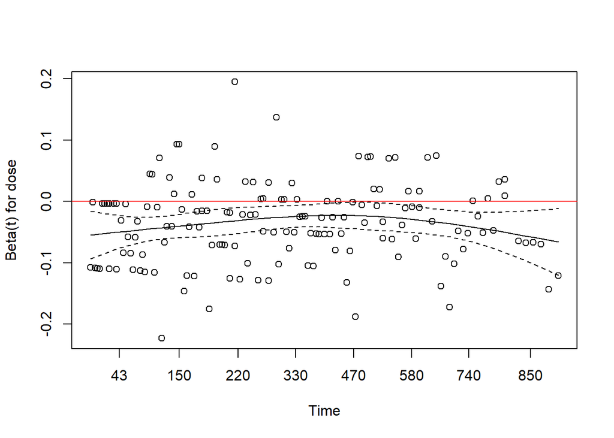

```r
plot(cox.zph(Mod2))
abline(h=0,col="red")
```

```r
Mod3= coxph(Surv(time,status_code)~dose+Depression,data=data)
summary(Mod3)
```

```
## Call:
## coxph(formula = Surv(time, status_code) ~ dose + Depression,
##     data = data)
##
##   n= 238, number of events= 150
##
##                   coef exp(coef)  se(coef)      z Pr(>|z|)
## dose         -0.036286  0.964364  0.006278 -5.780 7.46e-09 ***
## Depressionno  1.224191  3.401415  0.204746  5.979 2.24e-09 ***
## ---
## Signif. codes:  0 '***' 0.001 '**' 0.01 '*' 0.05 '.' 0.1 ' ' 1
##
##              exp(coef) exp(-coef) lower .95 upper .95
## dose            0.9644      1.037    0.9526    0.9763
## Depressionno    3.4014      0.294    2.2771    5.0809
##
## Concordance= 0.71  (se = 0.022 )
## Likelihood ratio test= 80.62  on 2 df,   p=<2e-16
## Wald test            = 68.24  on 2 df,   p=2e-15
## Score (logrank) test = 73.88  on 2 df,   p=<2e-16
```

```r
cox.zph(Mod3)
```

```
##             chisq df    p
## dose       0.1099  1 0.74
## Depression 0.0325  1 0.86
## GLOBAL     0.1411  2 0.93
```

## 0.14 Restricted Mean Survival:

Restricted mean survival time (RMST) is suggested as a novel alternative measure in survival analyses and may be useful when proportional hazards assumption cannot be made or when event rate is low.

Note that, previously we have seen that Median survival for the clinic 1 was not converged. So in this kind of scenario RMST are mostly used.

In R to do this RMST:

```r
#library(survRM2)
RMST_Clinic=rmst2(time = data$time,status = data$status_code,arm = (data$clinic=="Clinic1")*1,tau = 905)
RMST_Clinic
```

```
##
## The truncation time: tau = 905  was specified.
##
## Restricted Mean Survival Time (RMST) by arm
##                 Est.     se lower .95 upper .95
## RMST (arm=1) 643.783 40.079   565.229   722.337
## RMST (arm=0) 429.332 22.581   385.073   473.591
##
##
## Restricted Mean Time Lost (RMTL) by arm
##                 Est.     se lower .95 upper .95
## RMTL (arm=1) 261.217 40.079   182.663   339.771
## RMTL (arm=0) 475.668 22.581   431.409   519.927
##
##
## Between-group contrast
##                         Est. lower .95 upper .95 p
## RMST (arm=1)-(arm=0) 214.451   124.287   304.615 0
## RMST (arm=1)/(arm=0)   1.499     1.278     1.759 0
## RMTL (arm=1)/(arm=0)   0.549     0.401     0.752 0
```

- To get better understanding about RMST, go [click here](https://cran.r-project.org//web//packages//survRM2//vignettes//survRM2-vignette3-2.html)
- For more details: [click here](https://rajeshmajumderblog.netlify.app//blog//internal-project_viii//)